# Multiscale network complementarity

## Summary statistics of the network similarity

Overlap index:

```r
network_sim_df %>% pull(overlapindex) %>% summary
```

```
     Min.   1st Qu.    Median      Mean   3rd Qu.      Max.
0.0001835 0.0121798 0.0331371 0.0419274 0.0543372 0.4899776
```

Median overlap indices between co-expression networks are 0.0433192 and non co-expression networks are 0.0183954.

```r
## Jaccard heatmap

## remove coex_core from the map
p1 = network_sim_df[,1:3] %>% dplyr::filter(!grepl("core", V1), !grepl("core", V2)) %>%
  # heatmap plot
  ggplot() + geom_tile(aes(x = V1, y = V2, fill = jaccardIndex)) + scale_fill_distiller(direction = 1) + xlab("") +ylab("") + ggtitle("Jaccard similarity among all networks") + theme_minimal()+ theme(axis.text.x = element_text(angle = 90))

p1
```

[output not shown]

We use core transcriptional modules to represent all of the co-expression network. The heatmap below shows the Jaccard and Overlap similarity.

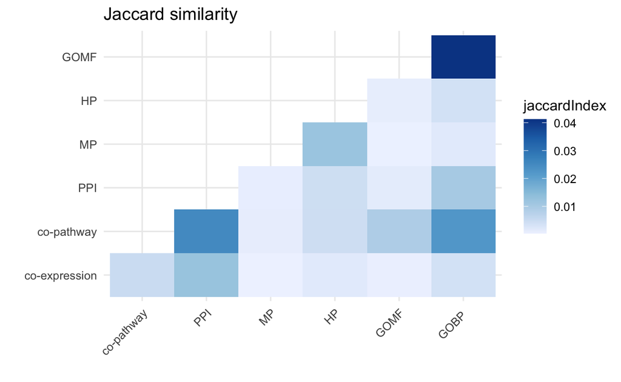

```r
## remove coex_core from the map
considered_networks = c("coex_core", "reactome_copathway", "ppi", "MP", "HP", "GOMF", "GOBP")

labels = c("co-expression", "co-pathway", "PPI", "MP", "HP", "GOMF", "GOBP ")

p1 = network_sim_df[,1:3] %>% dplyr::filter(V1 %in% considered_networks, V2 %in% considered_networks ) %>%
  # rescale factor
  mutate(V1 = factor(V1, levels = considered_networks, labels = labels),
         V2 = factor(V2, levels = considered_networks, labels = labels)) %>%
  # heatmap plot
  ggplot() + geom_tile(aes(x = V1, y = V2, fill = jaccardIndex)) + scale_fill_distiller(direction = 1) + xlab("") +ylab("") + ggtitle("Jaccard similarity") + theme_minimal() + theme(axis.text.x = element_text(angle = 45, hjust = 1))

p1
```

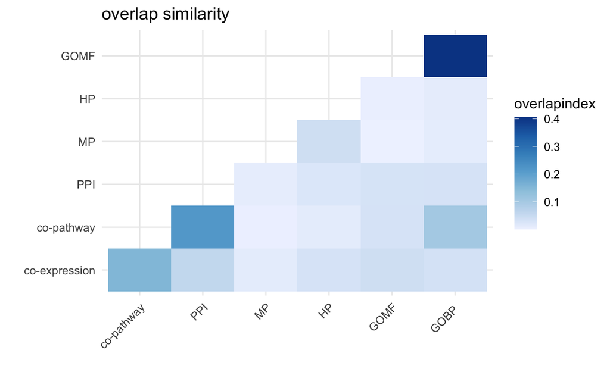

```r
overlap_df <- network_sim_df[,c(1,2,4)] %>% dplyr::filter(V1 %in% considered_networks, V2 %in% considered_networks ) %>%
  # rescale factor
  mutate(V1 = factor(V1, levels = considered_networks, labels = labels),
         V2 = factor(V2, levels = considered_networks, labels = labels))

  # heatmap plot
p2 = ggplot(overlap_df) + geom_tile(aes(x = V1, y = V2, fill = overlapindex)) + scale_fill_distiller(direction = 1) + xlab("") +ylab("") + ggtitle("overlap similarity ") + theme_minimal() + theme(axis.text.x = element_text(angle = 45, hjust=1))

p2
```

```r
sprintf("average overlap index for all networks are %f", mean(overlap_df$overlapindex))
```

```
[1] "average overlap index for all networks are 0.060363"
```

# Network similairty randomisation

For a given pair of network $g_A \in G(V_A, E_A)$ and $g_B \in G(V_A, E_A)$, we computed edge similarity through overlap index:

$$S_{AB}=\dfrac{|E_A \cap E_B|}{\text{min}(|E_A|,|E_B|)}$$

Foe each network, we performed 10 permutations of node indices, resulting in 100 permutations for a network pair, wehere we obtained the reference distribution for their similarity. We then computed $z$-score and the corresponding empirical $p$-value. A network pair with $p-$value < 0.05 is considered significant (`../source/network_overlap_randomisation.R`)

```r
pacman::p_load(tidyverse, patchwork, ggrepel, cowplot)

# Perform the randomisation, or load from cahe (recommend)
source("../source/network_overlap_randomisation.R")
```

```
[1] "load the precomputed value from cache"
```

```r
# network similarity values
network_sim_df <- readRDS("../cache/network_jaccard_overlap_similarity_df.RDS") %>%
  dplyr::filter(!grepl("core", V1), !grepl("core" , V2))

# edge counts
ecounts <- readRDS("../cache/network_complementarity_topological.RDS")%>%
  dplyr::filter(property=="Number of edges") %>%
  pull(value, name = network)

# compute minimum edge size for each pair
network_sim_df$min_ecount <- apply(network_sim_df, 1, function(x) min(ecounts[x[1]], ecounts[x[2]]))
```

```r
# process jaccard and overlap index
jaccard_index <- lapply(randomisation_overlap_result, function(x) x$intersect/x$union)
overlap_index <- lapply(1:length(randomisation_overlap_result), function(x)
  randomisation_overlap_result[[x]][['intersect']]/network_sim_df$min_ecount[x])

# compute mean and sd, zscore and pvalue
network_sim_df <- network_sim_df %>%
  mutate(jaccard.mean = sapply(jaccard_index, mean),
         jaccard.sd = sapply(jaccard_index, sd),

         overlap.mean = sapply(overlap_index, mean),
         overlap.sd = sapply(overlap_index, sd),

         jaccard.zscore = (jaccardIndex-jaccard.mean)/jaccard.sd,
          jaccard.pval = pnorm(jaccard.zscore, lower.tail = F),

          overlap.zscore = (overlapindex-overlap.mean)/overlap.sd,
          overlap.pval = pnorm(overlap.zscore, lower.tail = F)
  )


# label p values into classes
network_sim_df <- network_sim_df %>%
  # make p values in groups
  mutate(overlap.pval_level = cut(overlap.pval,
                                  breaks = rev(c(1,5e-2, 1e-3, 1e-4, 1e-5, 0)),
                                  labels = rev(c("ns","*","**","***","****")),
                                  include.lowest = T, ordered_result = T),
         # compute whether the pair are from both co-expression, or non co-expressions
         type1 = grepl("coex", V1),
         type2 = grepl("coex", V2),
         pair_name = paste(str_remove(V1,"coex_|reactome_"),
                           str_remove(V2,"coex_|reactome_"), sep = " - "),
         # label only if overlap score higher than 0.2
         pair_label = ifelse(overlapindex > 0.2, pair_name, ""),
         type_pair = factor(type1+type2, levels = 0:2, labels = c("non.coex - non.coex",
                                                                  "coex - non.coex",
                                                                  "coex - coex"))) %>%
  mutate(overlap.pval_level = factor(overlap.pval_level, levels = rev(levels(overlap.pval_level))))


network_sim_df %>% count(overlap.pval_level) %>% paged_table()
```

|  | overlap.pval_level | n |
| --- | --- | --- |
| 1 | ns | 35 |
| 2 | * | 31 |
| 3 | ** | 9 |
| 4 | *** | 5 |
| 5 | **** | 910 |

Despite their wide range of similarity scores, we found that 955 out of 990 network pairs (96.5%) are significantly more similar than random expectation.

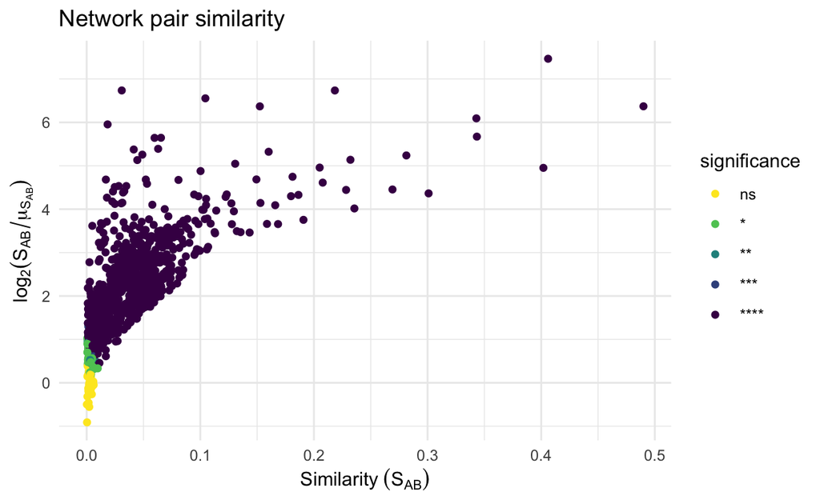

```r
# stable plot results
p_scatter = ggplot(network_sim_df, aes(x = overlapindex,
                                       y = log2(overlapindex/overlap.mean))) +
  geom_point(aes(col = overlap.pval_level)) +
  scale_colour_viridis_d(direction = -1) +
  theme_minimal() +
  xlab(expression(Similarity~(S[AB]))) + labs(title = "Network pair similarity", col = "significance") +
  ylab(expression(log[2](S[AB]/mu[S[AB]])))

# plot by type
p_scatter_by_type <- p_scatter + facet_grid(. ~ type_pair) + geom_text_repel(aes(label = pair_label))

p_scatter
```

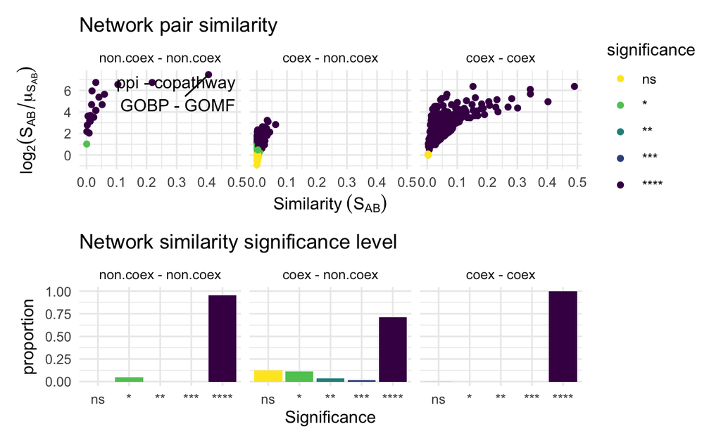

```r
pval_lv_count_df <- network_sim_df %>%  count(overlap.pval_level, name = "count")
pval_lv_count_by_type_df  <- network_sim_df %>%
  count(overlap.pval_level, type_pair, name = "count") %>%
  group_by(type_pair) %>%
  mutate(prop = count/sum(count))

p_count_by_type = ggplot(pval_lv_count_by_type_df, aes(x = overlap.pval_level, y = prop)) +
  geom_col(aes(fill = overlap.pval_level)) +
  scale_fill_viridis_d(direction = -1) +
  xlab("Significance") + ylab("proportion") + guides(fill = F) +
  theme_minimal() + facet_grid(. ~ type_pair) + labs(title = "Network similarity significance level")


p_scatter_by_type/p_count_by_type
```

Interestingly, we also observed that networks on different scales (i.e. among non co-expression layers) are all significantly similar, showing that there are key edges being maintained across genotype to phenotype.